# BTE Main Text Figures

Ze-Yi Han

8/11/2021

# Data

Data read in

We used log density to standardize the variance in protists density time series. Since in some days, the protists density is 0, and will result -INF by log(), we added 1 to all the density before calculating the log density for model fitting. We minused the 1 after exponentiating the model predictions.

```r
### data read in------
## density
milou_dens0 <- read.csv("/Users/zeyi/Documents/phd/Projects/Milou/02_Clean_data/Density.csv")
milou_dens <- milou_dens0  %>% mutate(tre=as.factor(tre), temp = as.factor(temp), nut = as.factor(nut), all_rep = rep(1:24, time = 24), log_density = log(density + 1)) %>% select(-1)
tetra <- milou_dens[which(milou_dens$Class=="Tetrahymena"),]
eup <- milou_dens[which(milou_dens$Class=="Euplotes"),]
bac0 <- read.csv("/Users/zeyi/Documents/phd/Projects/Milou/02_Clean_data/Milou_bac_OD.csv")
bac1 <- bac0 %>% mutate(tre = as.factor(tre), temp = as.factor(temp), nut = as.factor(nut), all_rep = rep(1:24, time = 11), temp_num = as.numeric(rep(c(22,25), each = 6, times = 22)), nut_num = as.numeric(rep(c(1,0.5), each = 12, times = 11)))
```

We calculated the mean and standard variation for bacteria OD after day 5. One data point that is more than 3 standard deviation away from the mean is removed.

```r
sd <- sd(bac1$OD[which(bac1$day > 5)], na.rm = TRUE)
mean <- mean(bac1$OD[which(bac1$day > 5)], na.rm = TRUE)
bac <- bac1[-which(bac1$OD > mean+3*sd),]
```

Since after population collapse, Tetrahymena are functionally extinct and so, even if we occasionally found individual, trait distributions are unreliable. For traits observation made after each Tetrahymena treatment collapsed (once population density became 0 ind/ml) that with less than 10 number of individual, we considered them unreliable and, thus, removed for future analysis.

```r
## trait
t_summ0 <- fread("/Users/zeyi/Documents/phd/Projects/Milou/02_Clean_data/Milou_trait_summary.csv")
t_summ <- t_summ0 %>% mutate(rep = as.character(rep),
         tre = as.factor(tre),temp_num = as.numeric(temp_num), nut_num = as.numeric(nut_num),rep = as.factor(rep), tre = as.factor(tre), all_rep = rep(1:24, time = 24), temp = as.factor(temp), nut = as.factor(nut))
tetraSumm <- t_summ %>% filter(Class =="Tetrahymena")
eupSummtrait <- t_summ %>% filter(Class =="Euplotes")

# replace NA for tetra trait}
# Half 22C
tetraSumm[, 14:20][which(tetraSumm$tre=="Half22C" & tetraSumm$day>10 & tetraSumm$num_ind<10)] <- NA
# Full 22C
tetraSumm[, 14:20][which(tetraSumm$tre=="Full22C" & tetraSumm$day>11 & tetraSumm$num_ind<10)] <- NA
# Half 25C
tetraSumm[, 14:20][which(tetraSumm$tre=="Half25C" & tetraSumm$day>8 & tetraSumm$num_ind<10)] <- NA
# Full 25C
tetraSumm[, 14:20][which(tetraSumm$tre=="Full25C" & tetraSumm$day>8 & tetraSumm$num_ind<10)] <- NA

# trait group mean
tetraSummMean <- tetraSumm %>% na.omit %>% group_by(Class,temp,nut,tre,day) %>% summarise(mArea = mean(area)) %>% filter(day <= 9)
eupSummMean <- eupSummtrait %>% na.omit %>% group_by(Class,temp,nut,tre,day) %>% summarise(mArea = mean(area)) %>% filter(day <= 9) %>% filter(day <= 9)

# cropped time series for second version of CCM
tetraSumm_crop <- tetraSumm %>% filter(day <= 9)
eupSumm_crop <- eupSummtrait %>% filter(day <=9)
```

# Figure 1

Calculate mean density of Bacteria, Tetrahymena, and Euplotes

```r
bac.2 <- bac %>%
  rename(density = OD) %>%
  select(tre:density,treatNum) %>%
  mutate(temp = as.factor(temp))

teb.all <- milou_dens %>%
 select(tre:density,temp_num,-temp,treatNum)  %>%
  rename(temp = temp_num) %>%
  mutate(temp = as.factor(temp), nut = as.factor(nut),day = as.numeric(day))%>%
  full_join(bac.2) %>%
  na.omit() %>%
  group_by(Class,tre,treatNum, nut, temp,day) %>%
  summarise(mean.d = mean(density),
            log.d = log(mean.d +1)) %>%
  mutate(day = as.numeric(day))

teb.mean <- teb.all %>%
 select(Class:mean.d) %>%
  spread(key=Class, value = mean.d)
```

## Fig 1a. Overall average ecological dynamics

```r
dens1 <- tetra %>% group_by(day) %>% summarise(tetra = log(mean(density+1)), t.err = sd(density+1)/sqrt(24), t.err.log = log(t.err))
d.eup <- eup %>% group_by(day) %>% summarise(eup = log(mean(density+1)), eup.err = sd(density+1)/sqrt(24), eup.err.log = log(eup.err) )
dens2 <- right_join(dens1,d.eup)
d.bac <- bac %>% group_by(day) %>% na.omit() %>% summarise(bac = mean(OD), bac.err = sd(OD)/sqrt(24))
dens <- full_join(dens2,d.bac)
```

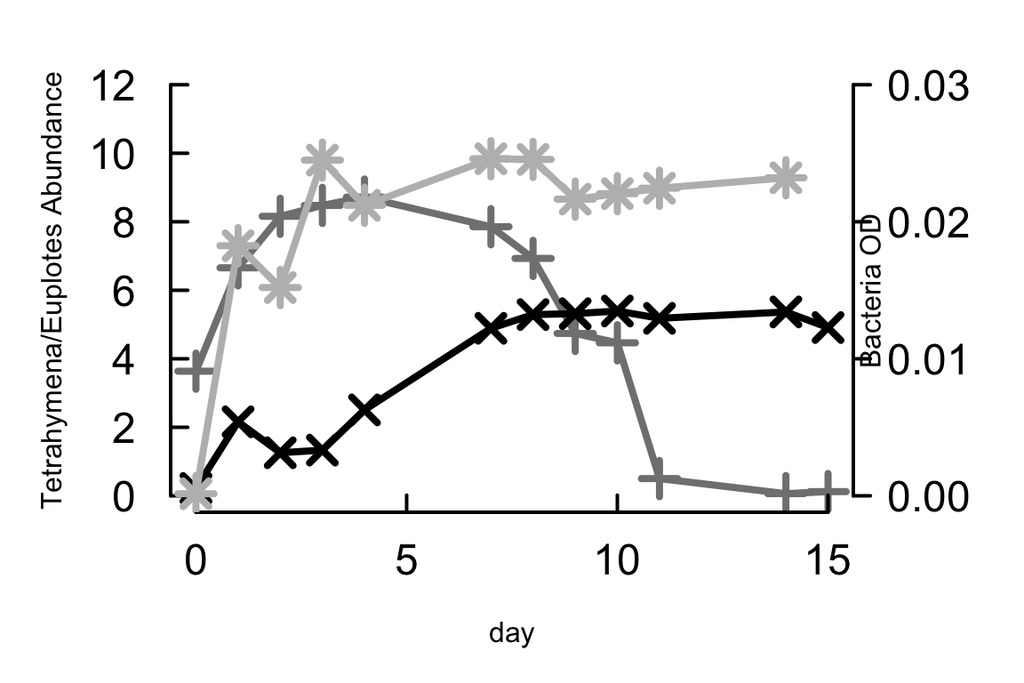

```r
# Tetrahymena and Euplotes average abundance
par(mar = c(5,5,2,5),tcl = 0.5)
with(dens, plot(day, tetra, type="o",pch=3, cex =2, lwd = 4,col="#818181", ylab="Tetrahymena/Euplotes Abundance", ylim=c(0,12), axes = F))
axis(side = 1,las=1,cex.axis=1.5,lwd = 2)
axis(side = 2,las=1,cex.axis=1.5,lwd = 2)
lines(dens$day,dens$eup, col = "black", lwd = 4) #lty = 2
points(dens$day,dens$eup, col = "black", pch =4, cex =2,lwd = 4)
# Bacteria average OD
par(new = T,tcl = -0.5)
with(dens, plot(day,bac, type="o", col ="#bcbcbc", cex=2, ylim=c(0, 0.03), lwd = 4, pch = 8,axes=F, xlab=NA, ylab=NA))
axis(side = 4, at = c(0, 0.01,0.02, 0.03),las=1,cex.axis=1.5,lwd = 2)
mtext(side = 4, 'Bacteria OD')
```

## Fig 1b-d. Gamm fits for the ecological dynamics

```r
# Bacteria ecological dyanmics
bm2 <- gamm(OD ~ s(day, by = tre, k =10) + tre,random = list(rep= ~ 1), data = bac, correlation = corARMA(form = ~ day|tre/rep, p = 2))
# Tetrahymena ecological dynamics
tm1 <- gamm(log_density ~ s(day, by = tre, k =10) + tre ,random = list(rep= ~ 1), data = tetra, correlation = corARMA(form = ~ day|tre/rep, p = 1))
# Euplotes ecological dynamics
em0 <- gamm(log_density ~ s(day, by = tre, k =10) + tre,random = list(rep= ~ 1), data = eup)

# function to predict tetrahymena, euplotes, and bacteria density from previous selected models
em0 <- gamm(log_density ~ s(day, by = tre, k =10) + tre,random = list(rep= ~ 1), data = eup)
tm1 <- gamm(log_density ~ s(day, by = tre, k =10) + tre ,random = list(rep= ~ 1), data = tetra, correlation = corARMA(form = ~ day|tre/rep, p = 1))
bm2 <- gamm(OD ~ s(day, by = tre, k =10) + tre ,random = list(rep= ~ 1), data = bac, correlation = corARMA(form = ~ day|tre/rep, p = 2))

pred_gam_TEB <- function(treatment,day, length){
  df <- data.frame(day=seq(0, day,length.out=length), tre=rep(treatment,length))
  eup_pred <-  exp(predict.gam(em0$gam,df,type = "response", se.fit =T)$fit)-1
  tetra_pred <-  exp(predict.gam(tm1$gam,df,type = "response", se.fit =T)$fit)-1
  bac_pred <- predict.gam(bm2$gam,df,type = "response", se.fit =T)$fit
  pred <- as.data.frame(cbind(df[, 1], eup_pred, tetra_pred, bac_pred))
  colnames(pred) <- c("day","eup_pred", "tetra_pred", "bac_pred" )
  pred
}

F22gam <- pred_gam_TEB("Full22C",15, 800)
F25gam <- pred_gam_TEB("Full25C",15, 800)
H22gam <- pred_gam_TEB("Half22C",15, 800)
H25gam <- pred_gam_TEB("Half25C",15, 800)

gam_all <- rbind(F22gam,F25gam,H22gam,H25gam) %>%
  mutate(tre=rep(c("Full22C", "Full25C", "Half22C", "Half25C"),each = 800),
         temp = rep(c(22,25,22,25), each=800),
         nut = rep(c("Full", "Half"), each=1600),
         day=rep(seq(0,15,length.out=800),4))
gam_gather <- gam_all%>%
  gather(key = "Class", value = "density", eup_pred, tetra_pred , bac_pred)
```

#### Fig 1b Bacteria overall ecological dynamics

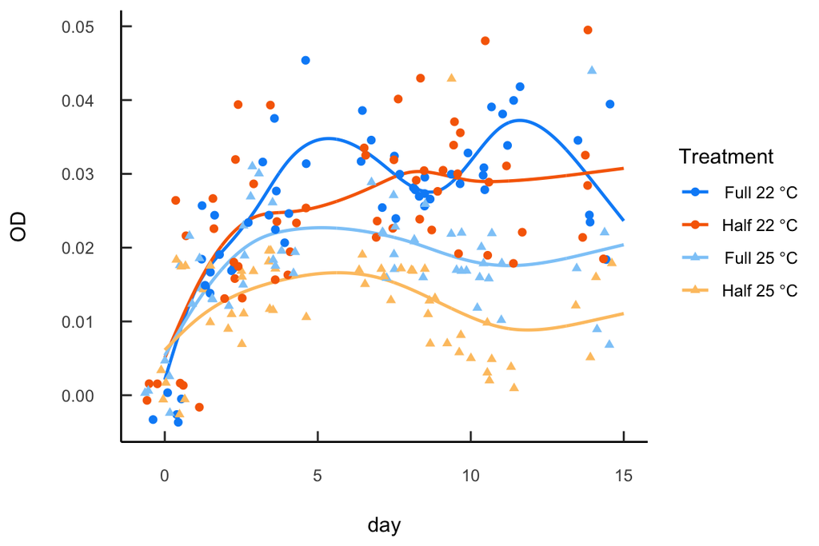

```r
trt_name <- c(expression(paste("Full 22 ",degree,"C")),expression(paste("Half 22 ",degree,"C")), expression(paste("Full 25 ",degree,"C")),expression(paste("Half 25 ",degree,"C")) )

# Bacteria
ggplot(data = bac, aes(x=day,y=OD,group = temp,shape = tre,colour = tre))+
  geom_line(data = gam_all, aes(x=day,y=bac_pred,group = tre, colour = tre), size = 0.8)+
  geom_jitter(size = 1.5, width = 0.7)+
  scale_colour_manual(name = "Treatment",labels = trt_name,values=c("#028ff7","#f76a02", "#8ecbf8", "#fdc470")) +
    scale_shape_manual(name = "Treatment", labels = trt_name, values = c(19, 19, 17, 17))+
  theme_bw()+theme(panel.border = element_blank(), panel.grid.major = element_blank(),
panel.grid.minor = element_blank(), axis.line = element_line(colour = "black"), axis.ticks.length=unit(-0.2, "cm"), axis.text.x = element_text(margin=unit(c(0.5,0.5,0.5,0.5), "cm")), axis.text.y = element_text(margin=unit(c(0.5,0.5,0.5,0.5), "cm")))
```

#### Fig 1c Tetrahymena overall ecological dynamics

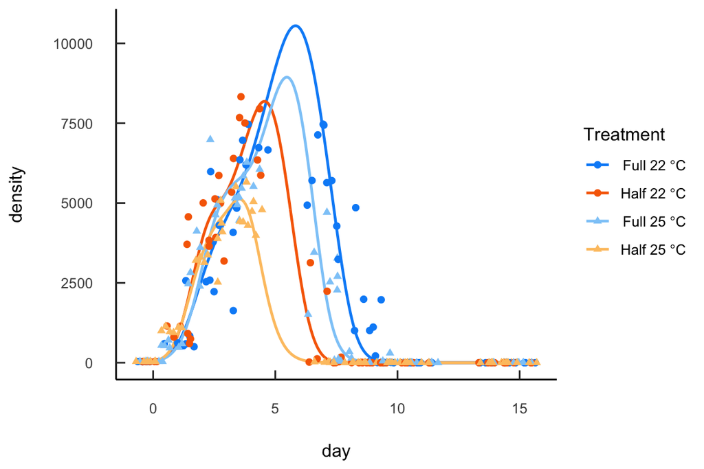

```r
# Tetrahymena
ggplot(data = tetra, aes(x=day,y=density,group = temp,shape = tre,colour = tre))+
  geom_line(data = gam_all, aes(x=day,y=tetra_pred,group = tre, colour = tre), size = 0.8)+
  geom_jitter(size = 1.5, width = 0.7)+
  scale_colour_manual(name = "Treatment",labels = trt_name,values=c("#028ff7","#f76a02", "#8ecbf8", "#fdc470")) +
    scale_shape_manual(name = "Treatment", labels = trt_name, values = c(19, 19, 17, 17))+
  theme_bw()+theme(panel.border = element_blank(), panel.grid.major = element_blank(),
panel.grid.minor = element_blank(), axis.line = element_line(colour = "black"), axis.ticks.length=unit(-0.2, "cm"), axis.text.x = element_text(margin=unit(c(0.5,0.5,0.5,0.5), "cm")), axis.text.y = element_text(margin=unit(c(0.5,0.5,0.5,0.5), "cm")))
```

#### Fig 1d Euplotes overall ecological dynamics

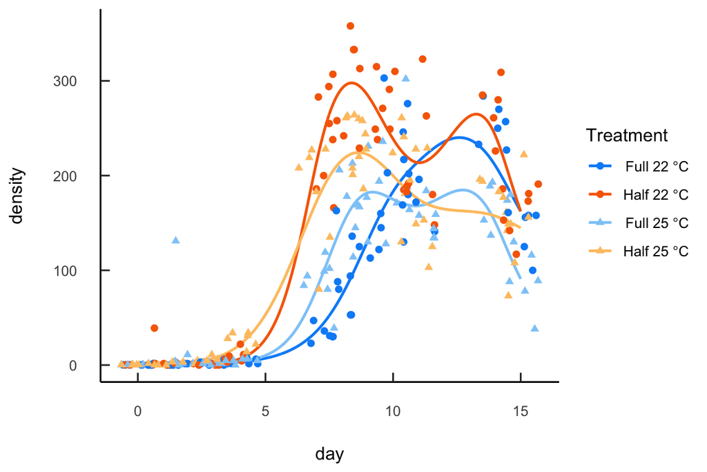

```r
# Euplotes
ggplot(data = eup, aes(x=day,y=density,group = temp,shape = tre,colour = tre)) +
  geom_line(data = gam_all, aes(x=day,y=eup_pred,group = tre, colour = tre), size = 0.8)+
geom_jitter(size = 1.5, width = 0.7)+
  scale_colour_manual(name = "Treatment",labels = trt_name,values=c("#028ff7","#f76a02", "#8ecbf8", "#fdc470")) +
    scale_shape_manual(name = "Treatment", labels = trt_name, values = c(19, 19, 17, 17))+
  theme_bw()+theme(panel.border = element_blank(), panel.grid.major = element_blank(),
panel.grid.minor = element_blank(), axis.line = element_line(colour = "black"), axis.ticks.length=unit(-0.2, "cm"), axis.text.x = element_text(margin=unit(c(0.5,0.5,0.5,0.5), "cm")), axis.text.y = element_text(margin=unit(c(0.5,0.5,0.5,0.5), "cm")))
```

## Fig 1e-f GAMM fits for phenotypic dynamics of Tetrahymena and Euplotes

#### Fig 1e Tetrahymena overall phenotypic dynamics

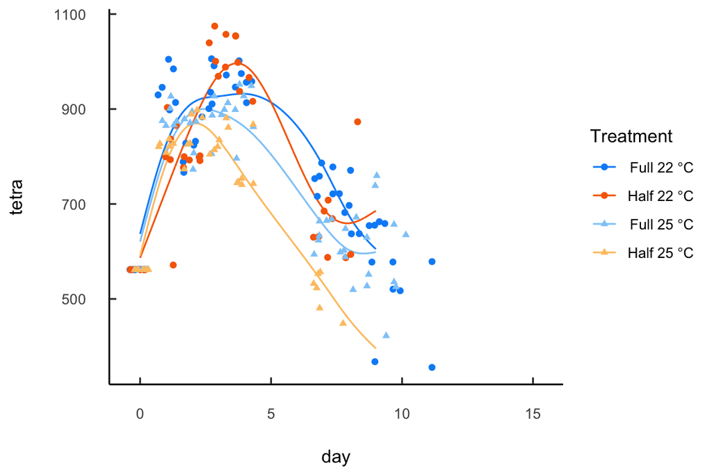

```r
tt3 <- gamm(area ~ s(day, by = tre, k =7) + tre,random = list(rep= ~ 1), data = tetraSumm, correlation = corARMA(form = ~ day|tre/rep, p = 3))
ttgam <- data.frame(day=rep(seq(0,9,length.out=500), 4), tre=rep(c("Full22C", "Full25C", "Half22C", "Half25C"),each = 500, 4))
ttgam$tetra <-  predict.gam(tt3$gam,ttgam,type = "response", se.fit =T)$fit

ggplot(ttgam, aes(x=day, y=tetra, color = tre, shape = tre))+ geom_line(width = 2) +
  geom_jitter(data= tetraSumm, aes(x=day, y = area, color=tre),size = 1.3, jitter = 0.7)+
  #geom_vline(xintercept=9,color = "#000000",  size = 0.3)+
   scale_colour_manual(name = "Treatment",labels = trt_name,values=c("#028ff7","#f76a02", "#8ecbf8", "#fdc470")) +
    scale_shape_manual(name = "Treatment", labels = trt_name, values = c(19, 19, 17, 17))+
  theme_bw()+theme(panel.border = element_blank(), panel.grid.major = element_blank(),
panel.grid.minor = element_blank(), axis.line = element_line(colour = "black"), axis.ticks.length=unit(-0.15, "cm"), axis.text.x = element_text(margin=unit(c(0.5,0.5,0.5,0.5), "cm")), axis.text.y = element_text(margin=unit(c(0.5,0.5,0.5,0.5), "cm")))
```

#### Fig 1f Euplotes overall phenotypic dynamics

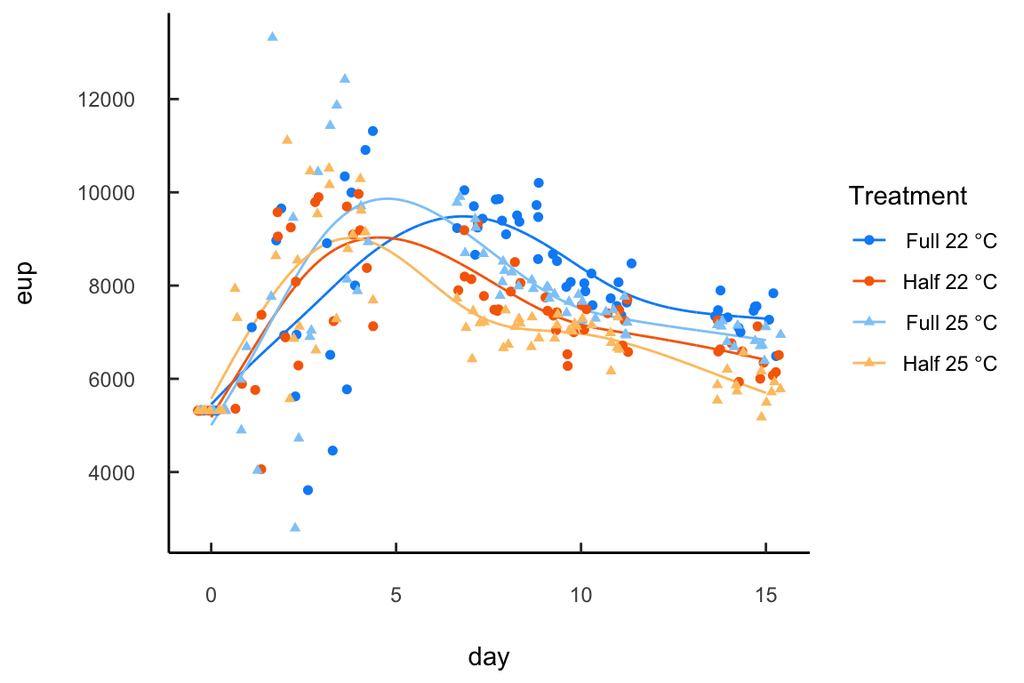

```r
# make days with number of individal less than 10 as NA
#eupSummtrait$area[which(eupSummtrait$num_ind < 11)] <- NA

et1 <- gamm(area ~ s(day, by=tre, k =9) + tre,random = list(rep= ~ 1), data = eupSummtrait, correlation = corARMA(form = ~ day|tre/rep, p = 1))
etgam <- data.frame(day=rep(seq(0,15,length.out=1000), 4), tre=rep(c("Full22C", "Full25C", "Half22C", "Half25C"),each = 1000, 4))
etgam$eup<-  predict.gam(et1$gam,etgam,type = "response", se.fit =T)$fit

ggplot(etgam, aes(x=day, y=eup, color = tre, shape = tre))+ geom_line(width = 2) +
  geom_jitter(data= eupSummtrait, aes(x=day, y = area, color=tre),size = 1.3, jitter = 0.7)+
   scale_colour_manual(name = "Treatment",labels = trt_name,values=c("#028ff7","#f76a02", "#8ecbf8", "#fdc470")) +
    scale_shape_manual(name = "Treatment", labels = trt_name, values = c(19, 19, 17, 17))+
  theme_bw()+theme(panel.border = element_blank(), panel.grid.major = element_blank(),
panel.grid.minor = element_blank(), axis.line = element_line(colour = "black"), axis.ticks.length=unit(-0.15, "cm"), axis.text.x = element_text(margin=unit(c(0.5,0.5,0.5,0.5), "cm")), axis.text.y = element_text(margin=unit(c(0.5,0.5,0.5,0.5), "cm")))
```

# Fig 2 Interactive plot of temperature and nutrients effects on ecological dynamics

## Descriptors for Species Ecological Dynamics

The following are ecological dynamics descriptor calculated for each species.

#### 1. Bacteria ecological dynamics descriptor

- Initial growth
- Maximum abundance
- Coefficient of variation (CV)

```r
## New data frame
bac_desc <- data.frame("tre" = rep(c("Full22C", "Full25C", "Half22C", "Half25C"), each = 6))
bac_desc<- bac_desc %>%
  mutate(temp = as.factor(rep(c(22,25), each=6, times=2)),
         nut = factor(rep(c("Full","Half"), each=12), levels = c("Half", "Full")),
         rep = rep(1:6, times = 4))

## initial growth rate of Bacteria from day0 to day 1
bac_day0 <- bac[which(bac$day == 0), ]
bac_day1 <- bac[which(bac$day == 1), ]
bac_desc$init_growth <- (bac_day1$OD-bac_day0$OD)/8

## max abundance: three days with the top three population density
bac_max1<- teb.mean%>% group_by(tre,treatNum) %>% select(tre:day,Bacteria) %>% na.omit() %>%  arrange(desc(Bacteria), .by_group = TRUE)%>% slice_max(Bacteria, n=3)

bm1 <- bac %>% filter(tre == "Full22C", day %in% bac_max1$day[which(bac_max1$tre=="Full22C")])
bm2 <- bac %>% filter(tre == "Full25C", day %in% bac_max1$day[which(bac_max1$tre=="Full25C")])
bm3 <- bac %>% filter(tre == "Half22C", day %in% bac_max1$day[which(bac_max1$tre=="Half22C")])
bm4 <- bac %>% filter(tre == "Half25C", day %in% bac_max1$day[which(bac_max1$tre=="Half25C")])

bac_max <- rbind(bm1, bm2, bm3,bm4) %>% select(tre:temp, OD, -Date)
bac_max$nut <- factor(bac_max$nut, levels =  c("Half", "Full"))

# CV
bac_desc<- bac%>% group_by(tre,rep) %>%na.omit()%>% summarize(sd = sd(OD), meanOD= mean(OD), CV = sd/mean) %>% full_join(bac_desc)

# mean
bac.mean_desc <- bac_desc %>%
  group_by(tre, nut, temp) %>%
  na.omit %>%
  summarise(ig = mean(init_growth),
            CV.m=mean(CV))
bac_max_mean <- bac_max %>% group_by(nut, temp,tre) %>% na.omit() %>% summarise(ODmax = mean(OD),ODse = sd(OD))
```

The data frames for bacteria initial growth and coefficient of variation (CV) looks like:

```r
head(bac_desc)
```

```
## # A tibble: 6 × 8
## # Groups:   tre [2]
##   tre       rep     sd meanOD    CV temp  nut   init_growth
##   <chr>   <int>  <dbl>  <dbl> <dbl> <fct> <fct>       <dbl>
## 1 Full22C     1 0.0105 0.0237 0.449 22    Full      0.00175
## 2 Full22C     2 0.0117 0.0251 0.500 22    Full      0.00213
## 3 Full22C     3 0.0126 0.0260 0.535 22    Full      0.00338
## 4 Full22C     4 0.0123 0.0270 0.525 22    Full      0.00275
## 5 Full22C     5 0.0109 0.0239 0.463 22    Full      0.00362
## 6 Full25C     1 0.0138 0.0302 0.586 25    Full      0.00312
```

```r
head(bac_max_mean)
```

```
## # A tibble: 4 × 5
## # Groups:   nut, temp [4]
##   nut   temp  tre      ODmax    ODse
##   <fct> <fct> <fct>    <dbl>   <dbl>
## 1 Half  22    Half22C 0.0233 0.00475
## 2 Half  25    Half25C 0.0167 0.00153
## 3 Full  22    Full22C 0.0343 0.00689
## 4 Full  25    Full25C 0.0311 0.00951
```

#### 2. Tetrahymena ecological dynamics descriptor

- Initial growth
- Maximum abundance
- Coefficient of variation (CV)
- Day of population collapse

```r
# new data frame
tetra_desc <- data.frame("tre" = rep(c("Full22C", "Full25C", "Half22C", "Half25C"), each = 6))
tetra_desc<-tetra_desc %>%
  mutate(temp = as.factor(rep(c(22,25), each=6, times=2)),
         nut = factor(rep(c("Full","Half"), each=12), levels = c("Half", "Full")),
         rep = rep(1:6, times = 4))

## initial growth rate of tetrahymena from day0 to day 1
tetra_day0 <- tetra%>% filter(day==0) %>% select(density)
tetra_day1 <- tetra%>% filter(day==1) %>% select(density)
tetra_desc$tetra.ig <- log(tetra_day1$density)-log(tetra_day0$density)

 ## max abundance
tetra_max1 <- teb.mean %>% group_by(tre,treatNum) %>% select(tre:day,Tetrahymena) %>% summarize(max = max(Tetrahymena))
tetra_max <- teb.mean %>% filter(Tetrahymena %in% tetra_max1$max)
tetra_desc <- tetra%>% filter(tre %in% tetra_max$tre & day %in% tetra_max$day)%>% select(tre,rep,density) %>% rename(max = density)%>% left_join(tetra_desc)

# CV
tetra_desc <- tetra%>% group_by(tre,rep) %>% summarize(sd = sd(density), mean= mean(density), CV = sd/mean)%>% full_join(tetra_desc)

## time collapse
tetra_desc <- tetra %>% group_by(tre,rep) %>% filter(density == 0) %>% summarize(tc = min(day)) %>% full_join(tetra_desc)

# mean of the descriptors
t.mean_desc <- tetra_desc %>%
  group_by(tre, nut, temp) %>%
  summarise(ig = mean(tetra.ig),
            max.m = mean(max),
            CV.m = mean(CV),
            tc.m = mean(tc))
```

Data frame looks like:

```r
head(tetra_desc)
```

```
## # A tibble: 6 × 10
## # Groups:   tre [1]
##   tre       rep    tc    sd  mean    CV   max temp  nut   tetra.ig
##   <chr>   <int> <int> <dbl> <dbl> <dbl> <dbl> <fct> <fct>    <dbl>
## 1 Full22C     1    10 2455. 1926.  1.27  6195 22    Full      2.77
## 2 Full22C     2    11 2841. 2309.  1.23  6354 22    Full      2.61
## 3 Full22C     3    14 2852. 2014.  1.42  7465 22    Full      3.12
## 4 Full22C     4    10 2599. 1911.  1.36  6966 22    Full      2.67
## 5 Full22C     5    10 2718. 2011.  1.35  6663 22    Full      2.82
## 6 Full22C     6    14 2704. 2545.  1.06  6733 22    Full      2.78
```

#### 3. Euplotes ecological dynamics descriptor

- Initial growth
- Maximum abundance
- Coefficient of variation (CV)
- Day of population peak

Data frame looks like:

```r
head(eup_desc)
```

```
## # A tibble: 6 × 11
## # Groups:   tre [1]
##   tre       rep    sd  mean    CV temp  nut   init_growth maxdp daypeak   max
##   <chr>   <int> <dbl> <dbl> <dbl> <fct> <fct>       <dbl> <dbl>   <int> <dbl>
## 1 Full22C     1  93.9  88.7  1.06 22    Full        0.782   246      10   227
## 2 Full22C     2  93.3  82.0  1.14 22    Full        0.675   250      14   250
## 3 Full22C     3 101.   87.6  1.15 22    Full        0.726   276      10   257
## 4 Full22C     4 104.   94.9  1.09 22    Full        0.738   284      14   284
## 5 Full22C     5  91.5  89.4  1.02 22    Full        0.815   270      14   270
## 6 Full22C     6 107.   89.6  1.19 22    Full        0.675   303      10   233
```

## Fig 2 a-c Initial growth

Here is the function to generate interactive plot.

```r
TEB_interactive <- function(data1,x1,y1,data2,x2,y2,y_label){
  p <- ggplot(data=data1, aes(x=x1, y=y1, group=temp, shape= tre,colour=tre)) +
    geom_line(data = data2, aes(x=x2, y=y2), size = 0.6, color = "#c3c3c3") +
    scale_x_discrete(limits=c("Half","Full")) +
    labs(y=y_label, x = "Nutrient") +
    geom_jitter(size = 2, shape = rep(c(1,2),each=12), width = 0.25) +
    stat_summary(fun.data = mean_se, geom = "errorbar", width=0.2, size = 0.5) +
    geom_point(data = data2, aes(x=x2, y=y2, group=temp, shape=tre, colour=tre), size = 3) +
    theme_bw() +
    theme(panel.border = element_blank(), panel.grid.major = element_blank(),panel.grid.minor = element_blank(), axis.line = element_line(colour = "black"),axis.ticks.length=unit(-0.12, "cm"), axis.text.x = element_text(margin=unit(c(0.25,0.25,0.25,0.25), "cm"),colour = "black"), axis.text.y = element_text(margin=unit(c(0.25,0.25,0.25,0.25), "cm"), colour = "black"),axis.ticks = element_line(colour = "black")) +
    scale_colour_manual(name = "Treatment",
                        labels = trt_name,
                        values=c("#028ff7","#f76a02", "#8ecbf8", "#fec398")) +
    scale_shape_manual(name = "Treatment",
                       labels = trt_name,
                       values = c(19, 19, 17, 17))
  print(p)
}
```

#### Fig 2a Bacteria initial growth

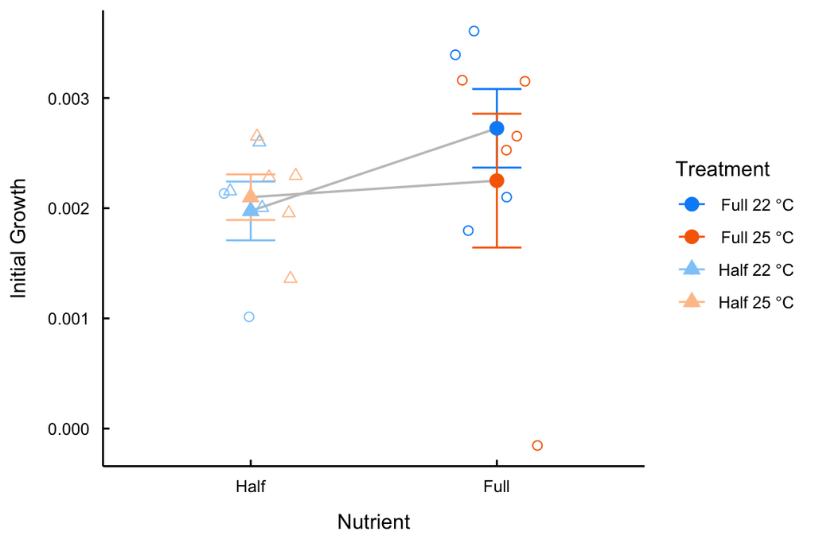

```r
trt_name <- c(expression(paste("Full 22 ",degree,"C")), expression(paste("Full 25 ",degree,"C")), expression(paste("Half 22 ",degree,"C")),expression(paste("Half 25 ",degree,"C")) )

# Bacteria initial growth
TEB_interactive(bac_desc,bac_desc$nut,bac_desc$init_growth,bac.mean_desc,bac.mean_desc$nut,bac.mean_desc$ig,"Initial Growth")
```

#### Fig 2b Tetrahymena initial growth

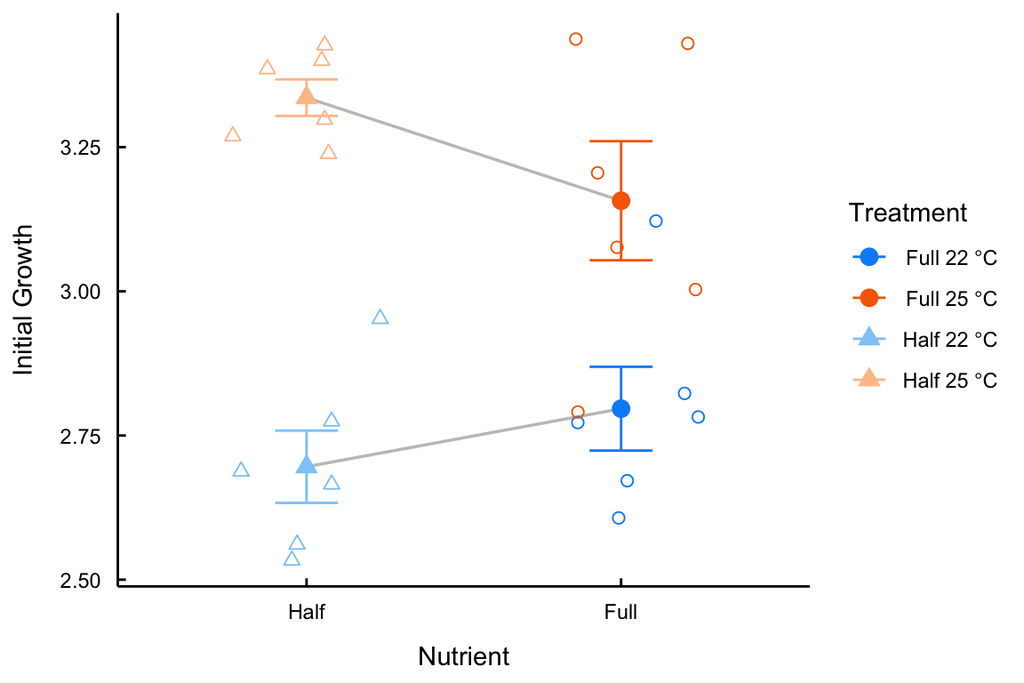

```r
# Tetrahymena initial growth
TEB_interactive(tetra_desc,tetra_desc$nut,tetra_desc$tetra.ig,t.mean_desc,t.mean_desc$nut,t.mean_desc$ig,"Initial Growth")
```

#### Fig 2c Euplotes initial growth

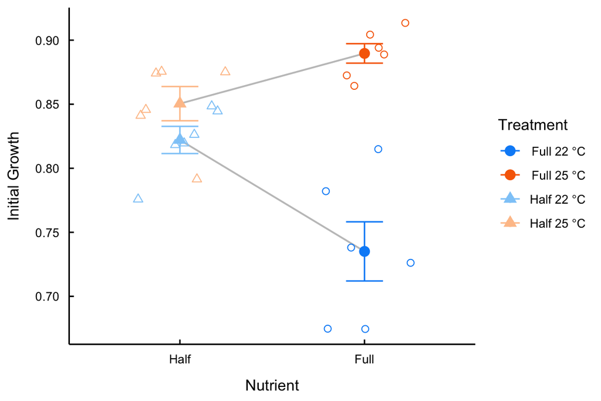

```r
# Euplotes initial growth
TEB_interactive(eup_desc,eup_desc$nut,eup_desc$init_growth,eup.mean_desc,eup.mean_desc$nut,eup.mean_desc$ig,"Initial Growth")
```

## Fig 2 d-f Maximum abundance

#### Fig 2d Bacteria Maximum Abundance

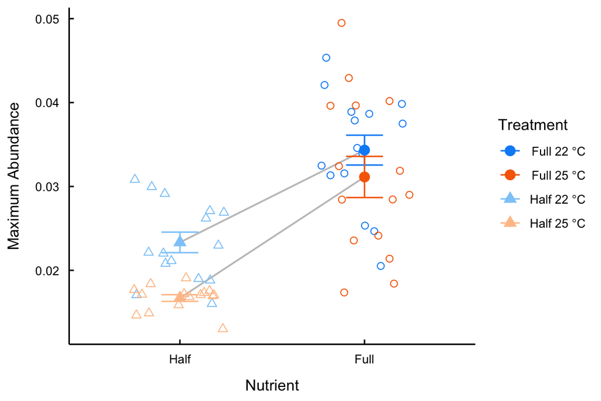

```r
TEB_interactive2 <- function(data1,x1,y1,data2,x2,y2,y_label){
  p <- ggplot(data=data1, aes(x=x1, y=y1, group=temp, shape= tre,colour=tre)) +
     geom_line(data = data2, aes(x=x2, y=y2), size = 0.6, color = "#c3c3c3") +
    scale_x_discrete(limits=c("Half","Full")) +
    labs(y=y_label, x = "Nutrient") +
    geom_jitter(size = 2, shape = rep(c(1,2),c(36,36 )), width = 0.25) +
    stat_summary(fun.data = mean_se, geom = "errorbar", width=0.2, size = 0.5) +
    geom_point(data = data2, aes(x=x2, y=y2, group=temp, shape=tre, colour=tre), size = 3) +
    theme_bw() +
   theme(panel.border = element_blank(), panel.grid.major = element_blank(),panel.grid.minor = element_blank(), axis.line = element_line(colour = "black"),axis.ticks.length=unit(-0.12, "cm"), axis.text.x = element_text(margin=unit(c(0.25,0.25,0.25,0.25), "cm"),colour = "black"), axis.text.y = element_text(margin=unit(c(0.25,0.25,0.25,0.25), "cm"), colour = "black"),axis.ticks = element_line(colour = "black")) +
    scale_colour_manual(name = "Treatment",
                        labels = trt_name,
                        values=c("#028ff7","#f76a02", "#8ecbf8", "#fec398")) +
    scale_shape_manual(name = "Treatment",
                       labels = trt_name,
                       values = c(19, 19, 17, 17))
  print(p)
}

# Bacteria Maximum Abundance
TEB_interactive2(bac_max,bac_max$nut,bac_max$OD,bac_max_mean,bac_max_mean$nut,bac_max_mean$ODmax,"Maximum Abundance")
```

#### Fig 2e Tetrahymena Maximum Abundance

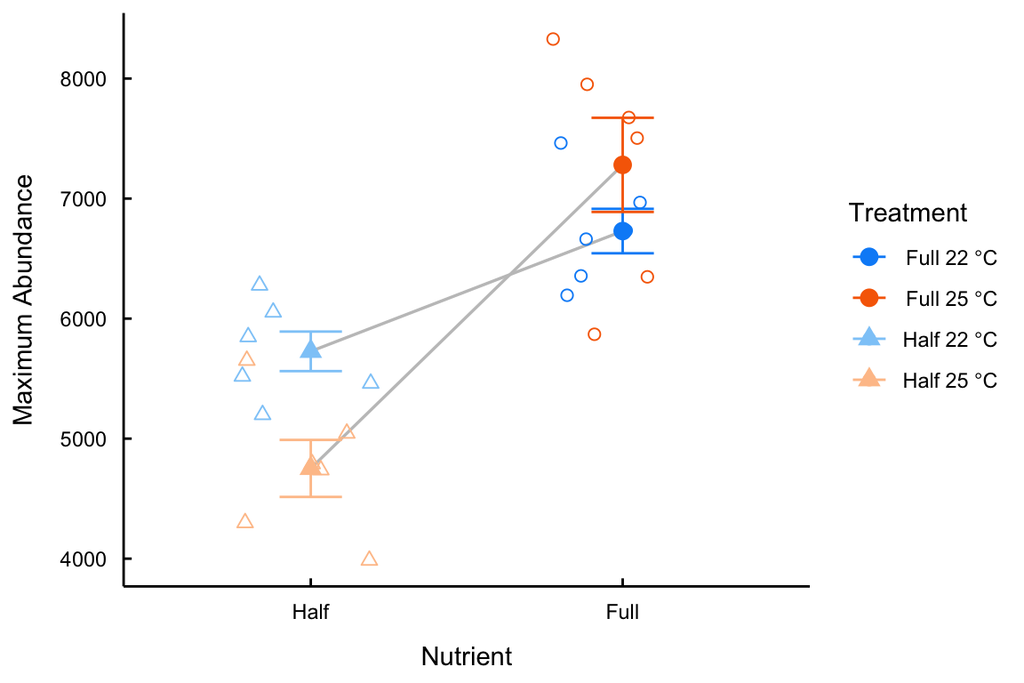

```r
# Tetrahymena Maximum Abundance
TEB_interactive(tetra_desc,tetra_desc$nut,tetra_desc$max,t.mean_desc,t.mean_desc$nut,t.mean_desc$max.m,"Maximum Abundance")
```

#### Fig 2f Euplotes Maximum Abundance

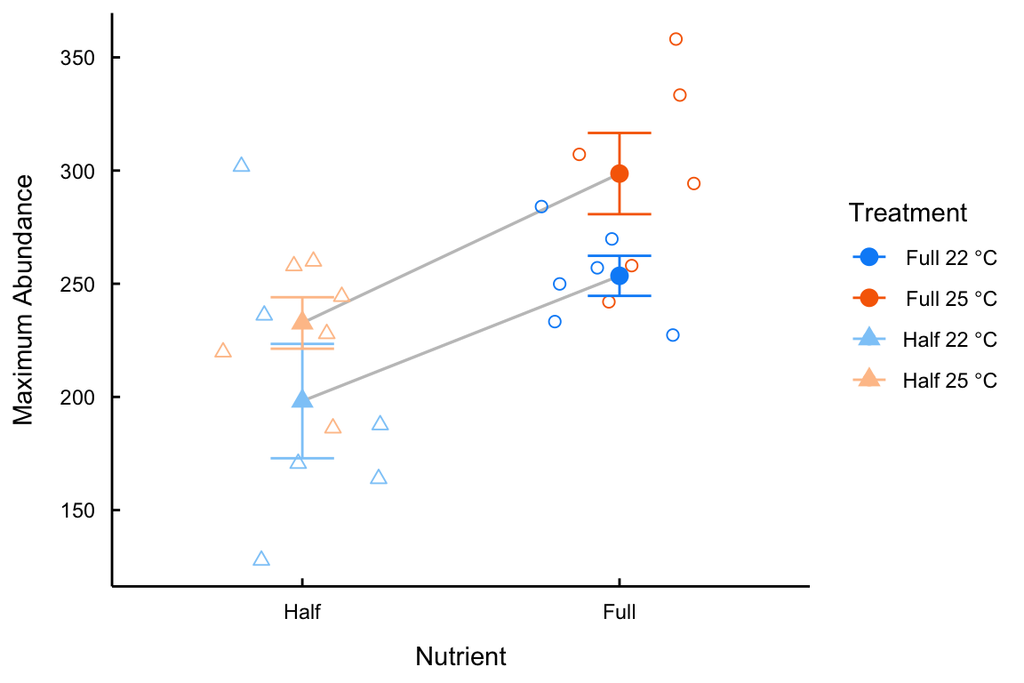

```r
# Euplotes Maximum Abundance
TEB_interactive(eup_desc,eup_desc$nut,eup_desc$max,eup.mean_desc,eup.mean_desc$nut,eup.mean_desc$max.m,"Maximum Abundance")
```

## Fig 2 g-i Coefficient of vairation (CV)

#### Fig 2g Bacteria CV

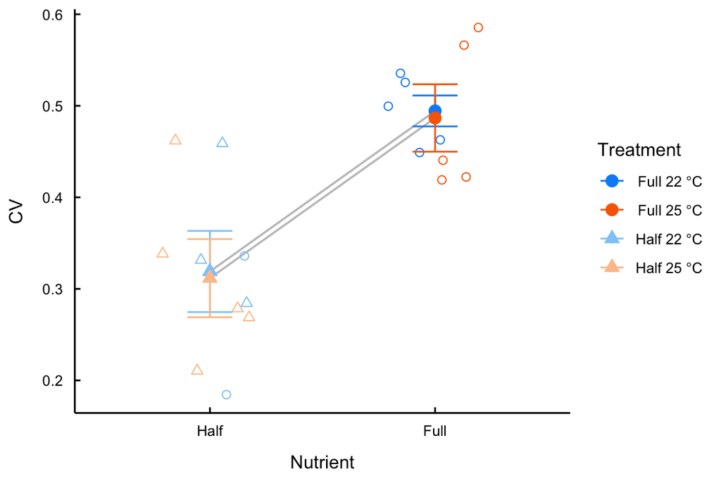

```r
# Bacteria CV
TEB_interactive(bac_desc,bac_desc$nut,bac_desc$CV,bac.mean_desc,bac.mean_desc$nut,bac.mean_desc$CV.m,"CV")
```

#### Fig 2h Tetrahymena CV

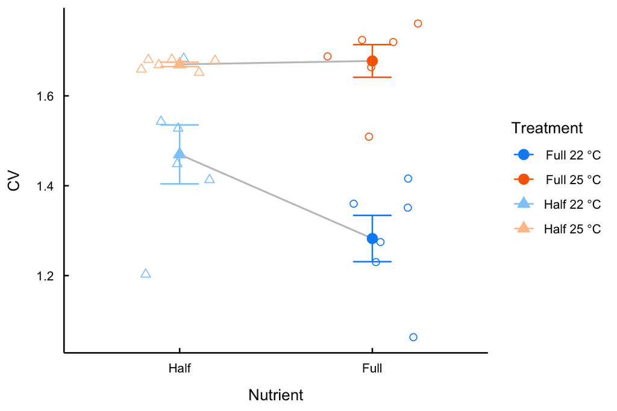

```r
# Tetrahymena CV
TEB_interactive(tetra_desc,tetra_desc$nut,tetra_desc$CV,t.mean_desc,t.mean_desc$nut,t.mean_desc$CV.m,"CV")
```

#### Fig 2i Euplotes CV

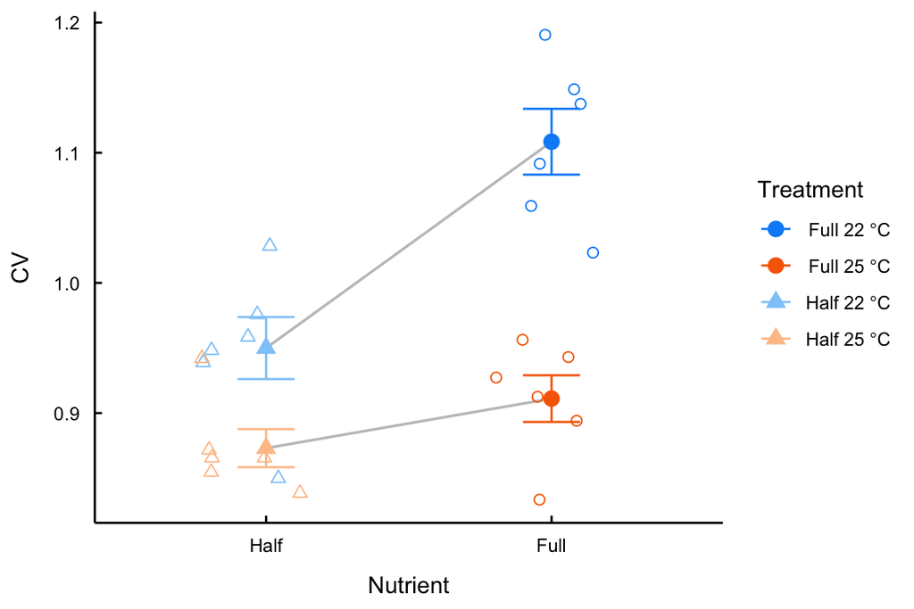

```r
# Euplotes CV
TEB_interactive(eup_desc,eup_desc$nut,eup_desc$CV,eup.mean_desc,eup.mean_desc$nut,eup.mean_desc$CV.m,"CV")
```

## Fig 2j Day of collapse of Tetrahymena

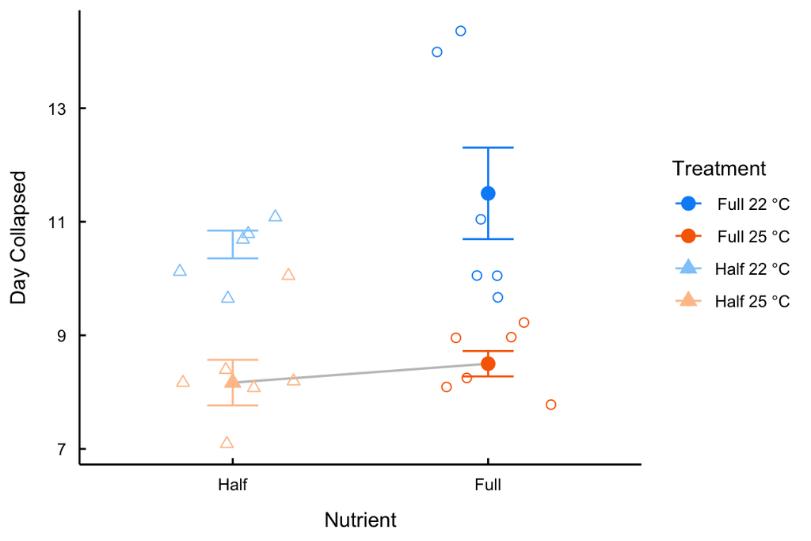

```r
# Tetrahymena Time Collapes
TEB_interactive(tetra_desc,tetra_desc$nut,tetra_desc$tc,t.mean_desc,t.mean_desc$nut,t.mean_desc$tc.m,"Day Collapsed")
```

## Fig 2k Day of peak of Euplotes

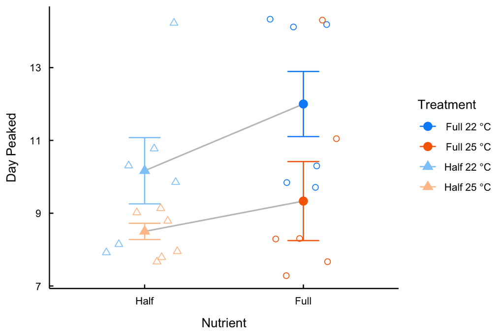

```r
 # Euplotes Day peaking
TEB_interactive(eup_desc,eup_desc$nut,eup_desc$daypeak,eup.mean_desc,eup.mean_desc$nut,eup.mean_desc$daypeak.m,"Day Peaked")
```

# Fig 3 Significant effects of Temperature and nutrients

All the linear models for temperature and nutrients effects can be found in appendix I Table S3 and the code for the models can be found in Rmarkdown file for appendix. Here we added up the significant additive temperature and nutrients effects and their interactions on species initial growh, maximum abundance and CV to plot Figure 3.

```r
TN_count <- as.data.frame(matrix(c(rep(NA,12) ), 3, 4))
colnames(TN_count) <- c("species","Temp", "Nut","T*N")
TN_count[,1] <- c("Bacteria", "Tetrahymena","Euplotes")
TN_count[1,2:4] <- c(1, 2, 0)
TN_count[2,2:4] <- c(3, 2, 2)
TN_count[3,2:4] <- c(2, 3, 2)
TN_count_ga <-gather(TN_count,key=effects, value = Counts,"Temp", "Nut","T*N" );TN_count_ga
```

```
##       species effects Counts
## 1    Bacteria    Temp      1
## 2 Tetrahymena    Temp      3
## 3    Euplotes    Temp      2
## 4    Bacteria     Nut      2
## 5 Tetrahymena     Nut      2
## 6    Euplotes     Nut      3
## 7    Bacteria     T*N      0
## 8 Tetrahymena     T*N      2
## 9    Euplotes     T*N      2
```

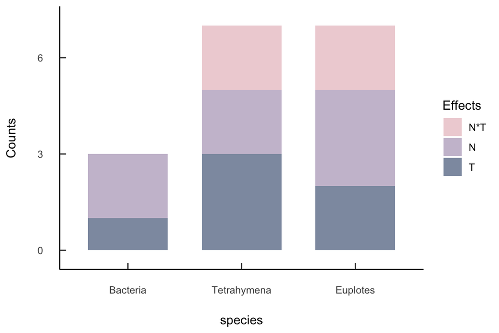

```r
 ggplot(data=TN_count_ga, aes(x=species, y=Counts, fill=factor(effects,levels = c("T*N","Nut","Temp")))) +
  geom_bar(stat="identity", width=0.7)+
  scale_x_discrete(limits = c("Bacteria", "Tetrahymena","Euplotes"))+
   scale_y_discrete(limits = c(0,3,6,9))+
  scale_fill_manual(name = "Effects",labels = c("N*T","N", "T"),values=c("#efd3d7" ,"#cbc0d3","#8e9aaf")) +
  theme_bw()+theme(panel.border = element_blank(), panel.grid.major = element_blank(),
panel.grid.minor = element_blank(), axis.line = element_line(colour = "black"), axis.ticks.length=unit(-0.2, "cm"), axis.text.x = element_text(margin=unit(c(0.5,0.5,0.5,0.5), "cm")), axis.text.y = element_text(margin=unit(c(0.5,0.5,0.5,0.5), "cm")))
```

# Fig 4 CCM predictability plot between speceices ecological and phenotypic dynamcis

To quantify the relationship between species ecological dynamics to one another, as well as their ecological dynamic to phenotypic dynamics, we use Congergent Cross Mapping (CCM, Sugihara et al 2012 Nature) to calculate the predictability of one time series to another. CCM can also distinguish between causality and correlation, giving us more understanding about if ecological and phentypic dynamcis are driving one other.

```r
# function to predict tetrahymena, euplotes, and bacteria density from previous selected models
em0 <- gamm(log_density ~ s(day, by = tre, k =10) + tre,random = list(rep= ~ 1), data = eup)
tm1 <- gamm(log_density ~ s(day, by = tre, k =10) + tre ,random = list(rep= ~ 1), data = tetra, correlation = corARMA(form = ~ day|tre/rep, p = 1))
bm2 <- gamm(OD ~ s(day, by = tre, k =10) + tre ,random = list(rep= ~ 1), data = bac, correlation = corARMA(form = ~ day|tre/rep, p = 2))

pred_gam_TEB <- function(treatment,day, length){
  df <- data.frame(day=seq(0, day,length.out=length), tre=rep(treatment,length))
  eup_pred <-  exp(predict.gam(em0$gam,df,type = "response", se.fit =T)$fit)-1
  tetra_pred <-  exp(predict.gam(tm1$gam,df,type = "response", se.fit =T)$fit)-1
  bac_pred <- predict.gam(bm2$gam,df,type = "response", se.fit =T)$fit
  pred <- as.data.frame(cbind(df[, 1], eup_pred, tetra_pred, bac_pred))
  colnames(pred) <- c("day","eup_pred", "tetra_pred", "bac_pred" )
  pred
}

F22gam <- pred_gam_TEB("Full22C",15, 800)
F25gam <- pred_gam_TEB("Full25C",15, 800)
H22gam <- pred_gam_TEB("Half22C",15, 800)
H25gam <- pred_gam_TEB("Half25C",15, 800)

# cropped time series for ecological dynamics
F22gam_crop <- pred_gam_TEB("Full22C",9, 500)
F25gam_crop <- pred_gam_TEB("Full25C",9, 500)
H22gam_crop <- pred_gam_TEB("Half22C",9, 500)
H25gam_crop <- pred_gam_TEB("Half25C",9, 500)
```

```r
# selected gamm model fpr tetrahymena and Euplotes trait
tt3 <- gamm(area ~ s(day, by = tre, k =7) + tre,random = list(rep= ~ 1), data = tetraSumm, correlation = corARMA(form = ~ day|tre/rep, p = 3))
et1 <- gamm(area ~ s(day, by=tre, k =9) + tre,random = list(rep= ~ 1), data = eupSummtrait, correlation = corARMA(form = ~ day|tre/rep, p = 1))

# predict Gamm function for trait
pred_gam_TEB_trait <- function(day, tModel, eModel, treatment, length, densityData){
  df <- data.frame(day=seq(0,day,length.out=length), tre=rep(treatment,length))
  eup_trait <-  predict.gam(eModel$gam,df,type = "response", se.fit =T)$fit
  tetra_trait <-  predict.gam(tModel$gam,df,type = "response", se.fit =T)$fit
  pred <- as.data.frame(cbind(densityData,eup_trait,tetra_trait))
}

# gam fit that goes into CCM
F22gam.area <- pred_gam_TEB_trait(15,tt3,et1,"Full22C", 800, F22gam)
F25gam.area <- pred_gam_TEB_trait(15,tt3,et1,"Full25C", 800, F25gam)
H22gam.area <- pred_gam_TEB_trait(15,tt3,et1,"Half22C", 800, H22gam)
H25gam.area <- pred_gam_TEB_trait(15,tt3,et1,"Half25C", 800, H25gam)

# Cropped time series for phenotypic dynamics, with cropped predicted ecological dynamics merged
F22gam.area_crop <- pred_gam_TEB_trait(9,tt3,et1,"Full22C", 500, F22gam_crop)
F25gam.area_crop <- pred_gam_TEB_trait(9,tt3,et1,"Full25C", 500, F25gam_crop)
H22gam.area_crop <- pred_gam_TEB_trait(9,tt3,et1,"Half22C", 500, H22gam_crop)
H25gam.area_crop <- pred_gam_TEB_trait(9,tt3,et1,"Half25C", 500, H25gam_crop)
```

We wrote two seperate functions for calculating the CCM predictability. All CCM pairs with tetrahymena trait datas, the model fits only include gamm model prediction from day 0 to day 9, since all Tetrahymena populations collaplse around day 9 based on gamm prediction.

```r
# this function only calculate the CCM analysis involve tetrahymena phenotypic dynamics. Here we cropped all the time series involving in these CCM.
CCM_TEB_trait_crop <- function(data, Em, libSize, nSamples){
  E_Xmap_Tt <- CCM(dataFrame=data, E=Em, columns = "eup_pred" , target = "tetra_trait", libSizes =  libSize,  sample = nSamples, random = TRUE, replacement = TRUE)
  Et_Xmap_Tt <- CCM(dataFrame=data, E=Em, columns = "eup_trait" , target = "tetra_trait", libSizes =  libSize,  sample = nSamples, random = TRUE, replacement = TRUE)
  T_Xmap_Tt <- CCM(dataFrame=data, E=Em, columns = "tetra_pred" , target =  "tetra_trait", libSizes =  libSize,  sample = nSamples, random = TRUE, replacement = TRUE)
  Tt_Xmap_B <- CCM(dataFrame=data, E=Em, columns =  "tetra_trait" , target =  "bac_pred", libSizes =  libSize,  sample = nSamples, random = TRUE, replacement = TRUE)

a <- list( "E_Xmap_Tt" = E_Xmap_Tt[,-3], "Tt_Xmap_E" = E_Xmap_Tt[,-2],  "Et_Xmap_Tt" = Et_Xmap_Tt[,-3], "Tt_Xmap_Et"= Et_Xmap_Tt[,-2], "T_Xmap_Tt" = T_Xmap_Tt[,-3],  "Tt_Xmap_T" = T_Xmap_Tt[,-2], "Tt_Xmap_B" = Tt_Xmap_B[,-3],  "B_Xmap_Tt" = Tt_Xmap_B[,-2])
}

# this function calculate all the rest CCM pairs that do not involve tetra trait data
# dateset from model prediction used in this function are different length from the ones used in the previous function

CCM_TEB_trait_full <- function(data, Em, libSize, nSamples){
  E_Xmap_T <- CCM(dataFrame=data, E=Em, columns ="eup_pred" , target =  "tetra_pred", libSizes =  libSize,  sample = nSamples, random = TRUE, replacement = TRUE)
  T_Xmap_B <- CCM(dataFrame=data, E=Em, columns ="tetra_pred" , target = "bac_pred", libSizes =  libSize,  sample = nSamples, random = TRUE, replacement = TRUE)
  E_Xmap_B <- CCM(dataFrame=data, E=Em, columns ="eup_pred" , target = "bac_pred",libSizes =  libSize,  sample = nSamples, random = TRUE, replacement = TRUE)
  Et_Xmap_T <- CCM(dataFrame=data, E=Em, columns ="eup_trait" ,target = "tetra_pred",libSizes =  libSize,  sample = nSamples, random = TRUE, replacement = TRUE)
  E_Xmap_Et <- CCM(dataFrame=data, E=Em, columns = "eup_pred", target = "eup_trait", libSizes =  libSize,  sample = nSamples, random = TRUE, replacement = TRUE)
  Et_Xmap_B <- CCM(dataFrame=data, E=Em, columns = "eup_trait" , target =  "bac_pred", libSizes =  libSize,  sample = nSamples, random = TRUE, replacement = TRUE)
a <- list("E_Xmap_T" = E_Xmap_T[,-3],"T_Xmap_E" = E_Xmap_T[,-2],  "T_Xmap_B" = T_Xmap_B[,-3], "B_Xmap_T" = T_Xmap_B[, -2], "E_Xmap_B" = E_Xmap_B[,-3], "B_Xmap_E"= E_Xmap_B[,-2],"E_Xmap_Et" = E_Xmap_Et[,-3], "Et_Xmap_E" = E_Xmap_Et[,-2], "Et_Xmap_T" = Et_Xmap_T[,-3], "T_Xmap_Et" = Et_Xmap_T[,-2], "Et_Xmap_B" = Et_Xmap_B[,-3],"B_Xmap_Et" = Et_Xmap_B[,-2])
}
```

We then calculated the mean CCM predictability from 100 replication.

```r
# calculating CCM involving tetrahymena trait dynamics, using cropped time series
F22CCM.area_crop <-CCM_TEB_trait_crop(F22gam.area_crop, 1, seq(10, 80, by = 10),100)
F25CCM.area_crop <-CCM_TEB_trait_crop(F25gam.area_crop, 1, seq(10, 80, by = 10),100)
H22CCM.area_crop <-CCM_TEB_trait_crop(H22gam.area_crop, 1, seq(10, 80, by = 10),100)
H25CCM.area_crop <-CCM_TEB_trait_crop(H25gam.area_crop, 1, seq(10, 80, by = 10),100)

# calculate the rest CCM using full time series
F22CCM.area <-CCM_TEB_trait_full(F22gam.area, 1, seq(10, 80, by = 10),100)
F25CCM.area <-CCM_TEB_trait_full(F25gam.area, 1, seq(10, 80, by = 10),100)
H22CCM.area <-CCM_TEB_trait_full(H22gam.area, 1, seq(10, 80, by = 10),100)
H25CCM.area <-CCM_TEB_trait_full(H25gam.area, 1, seq(10, 80, by = 10),100)
```

We then extracted the mean CCM predictability of each pair at the largest library size (libSizes = 80) to fill in the data frame. To do so, we first created a data frame for all of the highest CCM predictability for each CCM test we ran. “E_Xmap_Tt” in “mapping” column means the CCM test for the casual effects of Tetrahymena phenotypic dynamics on Euplotes ecological dynamics. It’s a bottom-up, written as “B.up”. It tests the effects phenotypic dynamics has on ecological dynamics, thus indicated as “PhenoEco” effects. It is a interaction between Euplotes and Tetrahymena, thus “ET” as species pair. For “pair” column, “T” denotes Tetrahymena, “E” denotes Euplotes, “B” for bacteria,and “Tetra” and “Eup” stands for the effects of one species’ ecological dynamics on its on phenotypic dynamics or vice versa.

The data frame for CCM at largest library length looks like:

```r
# create dataframe to store predictability at largest library size.
area.rho.max <- data.frame(mapping = rep(
  c("E_Xmap_Tt", "Tt_Xmap_E",  "Et_Xmap_Tt", "Tt_Xmap_Et", "T_Xmap_Tt","Tt_Xmap_T", "Tt_Xmap_B",  "B_Xmap_Tt", "E_Xmap_T","T_Xmap_E", "T_Xmap_B", "B_Xmap_T", "E_Xmap_B", "B_Xmap_E","E_Xmap_Et", "Et_Xmap_E", "Et_Xmap_T", "T_Xmap_Et", "Et_Xmap_B","B_Xmap_Et" ),time =4),direc = rep(c("B.up","T.down","B.up","T.down","Single", "Single","B.up","T.down","B.up","T.down","B.up","T.down","B.up","T.down","Single","Single", "B.up","T.down","B.up","T.down"), time = 4), dynamics = rep(c("PhenoEco", "EcoPheno", "PhenoPheno","PhenoPheno","PhenoEco", "EcoPheno","EcoPheno", "PhenoEco", "EcoEco", "EcoEco","EcoEco","EcoEco","EcoEco","EcoEco", "PhenoEco", "EcoPheno","EcoPheno", "PhenoEco","EcoPheno", "PhenoEco"), time = 4),tre = rep(c("Full22C", "Full25C", "Half22C", "Half25C"), each = 20),temp = rep(c("22C", "25C"), each = 20, time = 2),nut =rep(c("Full", "Half"), each = 40),nut2 =rep(c("High", "Low"), each = 40), pair = rep(c("ET","ET","Tetra","BT", "ET", "BT","BE","Eup","ET", "BE"), each = 2, time = 4), rho= rep(NA,80))

# extract predictability at largest library size 80
for (i in 1:8) {
  area.rho.max[i,9] <- F22CCM.area_crop[[i]][8,2]
  area.rho.max[i+20, 9] <- F25CCM.area_crop[[i]][8,2]
  area.rho.max[i+40, 9] <- H22CCM.area_crop[[i]][8,2]
  area.rho.max[i+60, 9] <- H25CCM.area_crop[[i]][8,2]
}

for (i in 1:12) {
  area.rho.max[i+8,9] <- F22CCM.area[[i]][8,2]
  area.rho.max[i+28, 9] <- F25CCM.area[[i]][8,2]
  area.rho.max[i+48, 9] <- H22CCM.area[[i]][8,2]
  area.rho.max[i+68, 9] <- H25CCM.area[[i]][8,2]
}

head(area.rho.max)
```

```
##      mapping  direc   dynamics     tre temp  nut nut2  pair        rho
## 1  E_Xmap_Tt   B.up   PhenoEco Full22C  22C Full High    ET  0.9977812
## 2  Tt_Xmap_E T.down   EcoPheno Full22C  22C Full High    ET  0.7652091
## 3 Et_Xmap_Tt   B.up PhenoPheno Full22C  22C Full High    ET  0.4901549
## 4 Tt_Xmap_Et T.down PhenoPheno Full22C  22C Full High    ET -0.1239942
## 5  T_Xmap_Tt Single   PhenoEco Full22C  22C Full High Tetra  0.4278232
## 6  Tt_Xmap_T Single   EcoPheno Full22C  22C Full High Tetra  0.2991898
```

## Main text figure 4

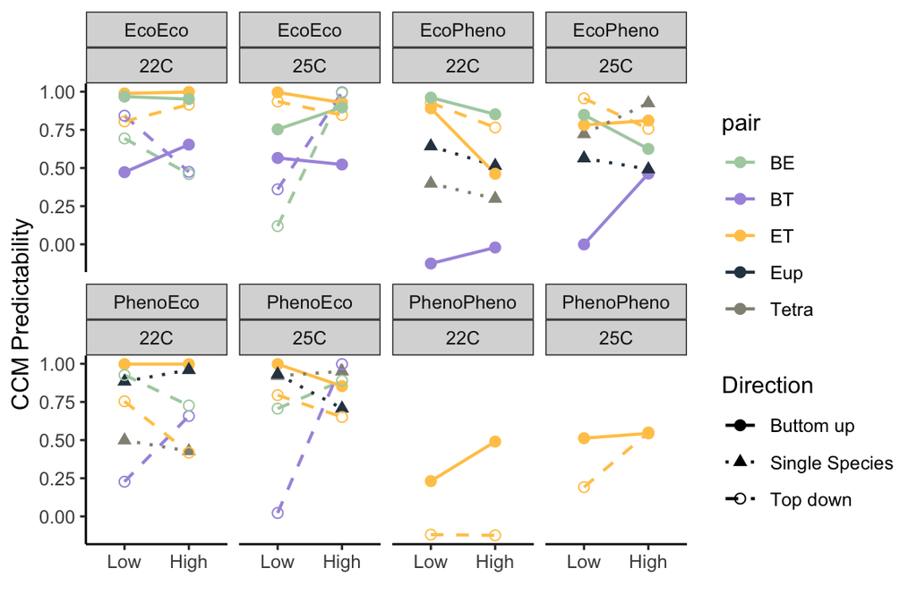

```r
ggplot(data = area.rho.max, aes(x=nut2, y=rho, group=mapping, color= pair,shape = direc, lty = direc)) +
  #geom_hline(yintercept=0.75,color = "#bcbcbc",  size = 0.3) +
  geom_line(data = area.rho.max, aes(x=nut2, y=rho),size = 0.7) +
  geom_point(size =2, strok =1) +
    scale_x_discrete(limits=c("Low","High")) +
    labs(y="CCM Predictability", x = "") +
  facet_wrap(~ dynamics + temp, nrow =2) +
    theme_bw() +
    theme(panel.border = element_blank(), panel.grid.major = element_blank(),panel.grid.minor = element_blank(), axis.line = element_line(colour = "black") ) +
    scale_colour_manual(values=  c("#add0af", "#A997DF", "#FFC857", "#2E4052", "#929084")) +
    scale_linetype_manual(name = "Direction", labels = c("Buttom up", "Single Species","Top down"), values = c(1,3,2)) +
    scale_shape_manual(name = "Direction", labels = c("Buttom up", "Single Species","Top down"), values = c(19, 17, 1))
```

# Fig 5 Strong Interaction between ecological and phenotypic dynamics

To be conservative and increase the chance of picking up biologically relevant effects, we consider effects whose CCM predictability value was above 0.75 as strong interaction. Here are the 40 strong interactions presented in Figure 5 in the main text. Explanation for the data frame can be found under Fig 4 section.

```r
StrongInter <- area.rho.max[which(area.rho.max$rho > 0.75),]
StrongInter
```

```
##      mapping  direc dynamics     tre temp  nut nut2  pair       rho
## 1  E_Xmap_Tt   B.up PhenoEco Full22C  22C Full High    ET 0.9977812
## 2  Tt_Xmap_E T.down EcoPheno Full22C  22C Full High    ET 0.7652091
## 9   E_Xmap_T   B.up   EcoEco Full22C  22C Full High    ET 0.9976658
## 10  T_Xmap_E T.down   EcoEco Full22C  22C Full High    ET 0.9151655
## 13  E_Xmap_B   B.up   EcoEco Full22C  22C Full High    BE 0.9512350
## 15 E_Xmap_Et Single PhenoEco Full22C  22C Full High   Eup 0.9595637
## 19 Et_Xmap_B   B.up EcoPheno Full22C  22C Full High    BE 0.8519633
## 21 E_Xmap_Tt   B.up PhenoEco Full25C  25C Full High    ET 0.8533647
## 22 Tt_Xmap_E T.down EcoPheno Full25C  25C Full High    ET 0.7567583
## 25 T_Xmap_Tt Single PhenoEco Full25C  25C Full High Tetra 0.9502915
## 26 Tt_Xmap_T Single EcoPheno Full25C  25C Full High Tetra 0.9249369
## 28 B_Xmap_Tt T.down PhenoEco Full25C  25C Full High    BT 0.9978469
## 29  E_Xmap_T   B.up   EcoEco Full25C  25C Full High    ET 0.9280965
## 30  T_Xmap_E T.down   EcoEco Full25C  25C Full High    ET 0.8471005
```

[output cut: 26 more lines]